# DS 7374 Project

## Model comparision and Recommended Threshold to use

```r
model.comparison = bind_rows(
  cost.value.Results %>%
    slice_max(net.financial.value, n = 1) %>%
    mutate(model = "Logistic Regression"),

  rf.cost.value %>%
    slice_max(net.financial.value, n = 1) %>%
    mutate(model = "Random Forest")
) %>%
  select(
    model,
    threshold,
    recall,
    precision,
    flagged_patients,
    true_positives,
    expected.readmission.avoided,
    estimated.savings,
    intervention.cost,
    net.financial.value
  )

model.comparison
```

| model | threshold | recall | precision | flagged_patients | true_positives | expected.readmission.avoided | estimated.savings | intervention.cost | net.financial.value |
| --- | --- | --- | --- | --- | --- | --- | --- | --- | --- |
| Logistic Regression | 0.1 | 0.6360035 | 0.1525871 | 9470 | 1445 | 289.0 | 3468000 | 1894000 | 1574000 |
| Random Forest | 0.1 | 0.7143486 | 0.1481921 | 10952 | 1623 | 324.6 | 3895200 | 2190400 | 1704800 |

## Model interpretation: Variable Importance

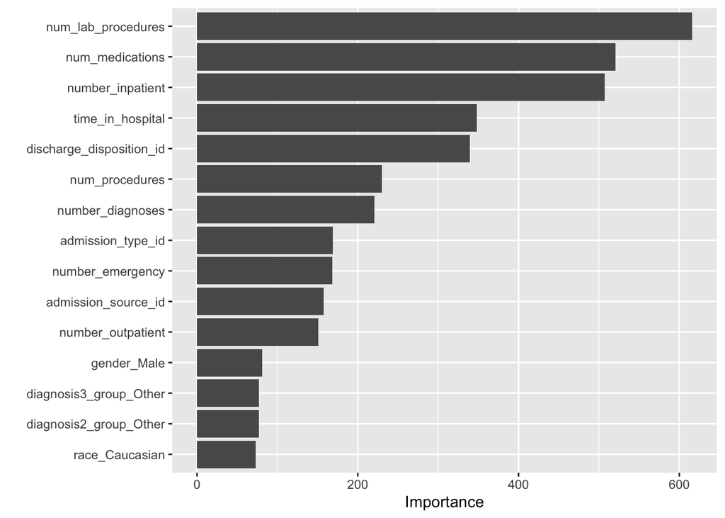

```r
library(vip)
rf.engine = extract_fit_parsnip(rf.fit)$fit
vip(rf.engine, num_features = 15)
```

The RF variable importance showed that the most influentials predictors included lab procedures, number of medications, prior inpatient visits, discharge disposition, time in hospital, number of procedures, number of diagnoses, emergency visits, admission type, admission source, and outpatient visits. These predictors reflect clincial complexity, prior healthcare ultiziation, and discharge-related factors. This support the business use case because patients with greater medical complexity or prior utilization may require more intensive post-dischare care-managment support.

## Final Model Recommendation

Use the random forest model with a 0.10 threshold when the goal is to maximize estimated net financial value, while allowing the dashboard user to adjust the threshold based on available care-management capacity.

## writing a clean file

```r
write.csv(diabetes_model, "diabetes_model_clean.csv", row.names = FALSE)
```